# Understanding Sales patterns and return dynamics in E-Commerce

Team 3

2024-12-08

# 1 Introduction

Shopping online has become a part of everyday life for many of us. From the convenience of browsing products from the comfort of our homes to having them delivered to our doorsteps, e-commerce has revolutionized how we shop. But what about the patterns behind these purchases, or the reasons why some products end up being returned? To better understand these dynamics, our team decided to dive into this fascinating topic.

By analyzing sales and return data from an e-commerce platform, we aim to uncover trends that drive sales performance and influence product returns. This analysis will help us better understand customer behavior, product preferences, and how businesses can optimize their strategies to reduce returns while enhancing the shopping experience.

## 1.1 Source of the Dataset

The dataset used for this analysis is sourced from Kaggle. The variables in the dataset include:

| Variable | Definition |
| --- | --- |
| Invoice number | A unique identifier for each sales transaction. |
| stock code | The code representing the product stock-keeping unit. |
| description | A brief description of the product. |
| quantity | The number of units of the product sold in the transaction |
| invoice date | The date and time when the sale was recorded. |
| unit price | The price per unit of the product in the transaction currency. |
| customer id | A unique identifier for each customer |
| country | The customer’s country. |
| warehouse location | The warehouse location from which the order was fulfilled. |
| Shipment Provider | The provider responsible for delivering the order. |
| Order Priority | The priority level of the order. |
| Discount | The discount applied to the transaction, if any. |
| Shipping cost | The cost of shipping for the transaction. |
| Sales channel | The channel through which the sale was made . |

## 1.2 SMART Framework Questions

The SMART framework was popularized by George T. Doran in a 1981 paper in Management Review. And we use this framework in our analysis to set goals that are clear, attainable, and meaningful.

**Specific:** The objective should be clear and state who will do what

**Measurable:** The objective should include how the action will be measured

**Achievable:** The objective should be realistic and attainable

**Relevant:** The objective should make sense and fit the purpose

**Time-bound:** The objective should include a timeline for expected results **[2]**

We have leverage the understanding of what a SMART question is and poured it into the following questions to be answered as part of our analysis;

**1)** What distinct customer segments can be identified by examining purchase frequency, product preferences, and payment methods, and how can these segments enhance personalized marketing efforts?

**2)**Which products exhibit the highest and most consistent demand, and how do factors like discounts, order priority, or customer demographics influence this demand over time?

**3)**How do variables like shipping costs, preferred shipment providers, and warehouse locations impact delivery times, cost-efficiency, and customer satisfaction?

**5)**What are the performance differences between online and in-store sales in terms of sales volume, customer satisfaction, and cost efficiency, and how do these inform channel-specific growth opportunities?

**6)**What are the primary patterns in product returns (by product type, discount status, customer segment), and how can these insights refine return policies to increase customer satisfaction and reduce return rates?

## 1.3 Exploratory Data Analysis

In the scholarly realm of data analysis, Exploratory Data Analysis (EDA) stands as a pivotal phase, akin to the preliminary investigations conducted by a seasoned researcher before embarking on a comprehensive study. Picture this phase as the initial survey of an unexplored scientific landscape, where the analyst endeavors to unearth latent patterns, identify anomalies, test hypotheses, and validate assumptions through a meticulous examination of summary statistics and graphical representations.

Exploratory Data Analysis refers to the critical process of performing initial investigations on data so as to discover patterns,to spot anomalies,to test hypothesis and to check assumptions with the help of summary statistics and graphical representations.**[3]**

The main purpose of EDA is to help look at data before making any assumptions. It can help identify obvious errors, as well as better understand patterns within the data, detect outliers or anomalous events, find interesting relations among the variables.**[4]**

Moreover, EDA validates assumptions, a process analogous to literature review and theoretical grounding in academic research. It ensures that the initial assumptions made about the dataset withstand scholarly scrutiny, providing a robust foundation for subsequent analyses.

## 1.4 Glimpse of a dataset

```r
data=read.csv("online_sales_dataset.csv")
head(data, 5)
```

```
##   InvoiceNo StockCode Description Quantity      InvoiceDate UnitPrice
## 1    221958  SKU_1964   White Mug       38 01-01-2020 00:00      1.71
## 2    771155  SKU_1241   White Mug       18 01-01-2020 01:00     41.25
## 3    231932  SKU_1501  Headphones       49 01-01-2020 02:00     29.11
## 4    465838  SKU_1760   Desk Lamp       14 01-01-2020 03:00     76.68
## 5    359178  SKU_1386   USB Cable      -30 01-01-2020 04:00    -68.11
##   CustomerID        Country Discount PaymentMethod ShippingCost    Category
## 1      37039      Australia 0.470000 Bank Transfer        10.79     Apparel
## 2      19144          Spain 0.190000       paypall         9.51 Electronics
## 3      50472        Germany 0.350000 Bank Transfer        23.03 Electronics
## 4      96586    Netherlands 0.140000       paypall        11.08 Accessories
## 5         NA United Kingdom 1.501433 Bank Transfer           NA Electronics
##   SalesChannel ReturnStatus ShipmentProvider WarehouseLocation OrderPriority
## 1     In-store Not Returned              UPS            London        Medium
## 2       Online Not Returned              UPS              Rome        Medium
## 3       Online     Returned              UPS            Berlin          High
## 4       Online Not Returned       Royal Mail              Rome           Low
## 5     In-store Not Returned            FedEx                          Medium
```

## 1.5 Structure and Summary of Dataset

```r
str(data)
```

```
## 'data.frame':    39432 obs. of  17 variables:
##  $ InvoiceNo        : int  221958 771155 231932 465838 359178 744167 210268 832180 154886 237337 ...
##  $ StockCode        : chr  "SKU_1964" "SKU_1241" "SKU_1501" "SKU_1760" ...
##  $ Description      : chr  "White Mug" "White Mug" "Headphones" "Desk Lamp" ...
##  $ Quantity         : int  38 18 49 14 -30 47 25 8 19 40 ...
##  $ InvoiceDate      : chr  "01-01-2020 00:00" "01-01-2020 01:00" "01-01-2020 02:00" "01-01-2020 03:00" ...
##  $ UnitPrice        : num  1.71 41.25 29.11 76.68 -68.11 ...
##  $ CustomerID       : int  37039 19144 50472 96586 NA 53887 46567 75098 87950 39718 ...
##  $ Country          : chr  "Australia" "Spain" "Germany" "Netherlands" ...
##  $ Discount         : num  0.47 0.19 0.35 0.14 1.5 ...
##  $ PaymentMethod    : chr  "Bank Transfer" "paypall" "Bank Transfer" "paypall" ...
##  $ ShippingCost     : num  10.79 9.51 23.03 11.08 NA ...
##  $ Category         : chr  "Apparel" "Electronics" "Electronics" "Accessories" ...
##  $ SalesChannel     : chr  "In-store" "Online" "Online" "Online" ...
##  $ ReturnStatus     : chr  "Not Returned" "Not Returned" "Returned" "Not Returned" ...
##  $ ShipmentProvider : chr  "UPS" "UPS" "UPS" "Royal Mail" ...
##  $ WarehouseLocation: chr  "London" "Rome" "Berlin" "Rome" ...
##  $ OrderPriority    : chr  "Medium" "Medium" "High" "Low" ...
```

```r
xkablesummary(data, title = "Summary of Dataset")
```

Summary of Dataset

|  | InvoiceNo | StockCode | Description | Quantity | InvoiceDate | UnitPrice | CustomerID | Country | Discount | PaymentMethod | ShippingCost | Category | SalesChannel | ReturnStatus | ShipmentProvider | WarehouseLocation | OrderPriority |
| --- | --- | --- | --- | --- | --- | --- | --- | --- | --- | --- | --- | --- | --- | --- | --- | --- | --- |
| Min | Min. :100005 | Length:39432 | Length:39432 | Min. :-50.00 | Length:39432 | Min. :-99.98 | Min. :10001 | Length:39432 | Min. :0.0000 | Length:39432 | Min. : 5.00 | Length:39432 | Length:39432 | Length:39432 | Length:39432 | Length:39432 | Length:39432 |
| Q1 | 1st Qu.:325815 | Class :character | Class :character | 1st Qu.: 11.00 | Class :character | 1st Qu.: 23.52 | 1st Qu.:32674 | Class :character | 1st Qu.:0.1300 | Class :character | 1st Qu.:11.22 | Class :character | Class :character | Class :character | Class :character | Class :character | Class :character |
| Median | Median :553023 | Mode :character | Mode :character | Median : 23.00 | Mode :character | Median : 48.65 | Median :55108 | Mode :character | Median :0.2600 | Mode :character | Median :17.50 | Mode :character | Mode :character | Mode :character | Mode :character | Mode :character | Mode :character |
| Mean | Mean :551139 | NA | NA | Mean : 22.39 | NA | Mean : 47.44 | Mean :54972 | NA | Mean :0.2761 | NA | Mean :17.51 | NA | NA | NA | NA | NA | NA |
| Q3 | 3rd Qu.:776620 | NA | NA | 3rd Qu.: 37.00 | NA | 3rd Qu.: 74.38 | 3rd Qu.:77318 | NA | 3rd Qu.:0.3800 | NA | 3rd Qu.:23.76 | NA | NA | NA | NA | NA | NA |
| Max | Max. :999997 | NA | NA | Max. : 49.00 | NA | Max. :100.00 | Max. :99998 | NA | Max. :1.9998 | NA | Max. :30.00 | NA | NA | NA | NA | NA | NA |
| NA | NA | NA | NA | NA | NA | NA | NA’s :3921 | NA | NA | NA | NA’s :1934 | NA | NA | NA | NA | NA | NA |

# 2 Cleaning Dataset

## 2.1 Looking For Null Values

```r
colSums(is.na(data))
```

```
##         InvoiceNo         StockCode       Description          Quantity
##                 0                 0                 0                 0
##       InvoiceDate         UnitPrice        CustomerID           Country
##                 0                 0              3921                 0
##          Discount     PaymentMethod      ShippingCost          Category
##                 0                 0              1934                 0
##      SalesChannel      ReturnStatus  ShipmentProvider WarehouseLocation
##                 0                 0                 0                 0
##     OrderPriority
##                 0
```

## 2.2 Removing Null Values

```r
data_clean<- na.omit(data)
```

```r
colSums(is.na(data_clean))
```

```
##         InvoiceNo         StockCode       Description          Quantity
##                 0                 0                 0                 0
##       InvoiceDate         UnitPrice        CustomerID           Country
##                 0                 0                 0                 0
##          Discount     PaymentMethod      ShippingCost          Category
##                 0                 0                 0                 0
##      SalesChannel      ReturnStatus  ShipmentProvider WarehouseLocation
##                 0                 0                 0                 0
##     OrderPriority
##                 0
```

```r
dim(data_clean)
```

```
## [1] 35511    17
```

## 2.3 Random Sample

```r
set.seed(123)
data_reduced <- data_clean %>% sample_n(10000)
```

```r
dim(data_reduced)
```

```
## [1] 10000    17
```

# 3 Detecting and Removing Outliers

An outlier is a data point that significantly deviates from the majority of other data points in a dataset, and in Exploratory Data Analysis (EDA), outliers can significantly affect the interpretation of data by skewing visualizations, impacting statistical measures like the mean, and potentially misleading conclusions drawn from the analysis if not properly identified and handled. Outliers can be unusually high or low compared to the majority of the data points.**[5]**

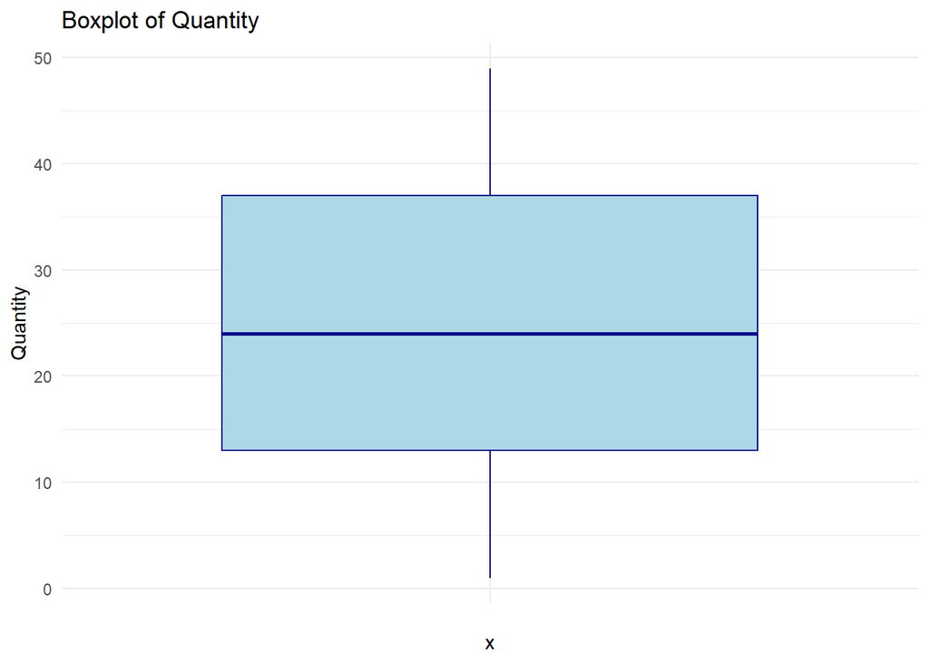

```r
ggplot(data_reduced, aes(x = "", y = Quantity)) +
    geom_boxplot(fill = "lightblue", color = "darkblue") +
    labs(title = "Boxplot of Quantity", y = "Quantity") +
    theme_minimal()
```

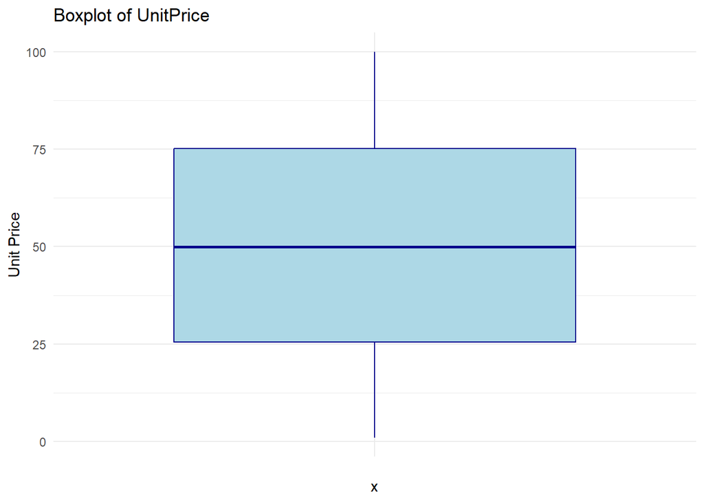

```r
ggplot(data_reduced, aes(x = "", y = UnitPrice)) +
    geom_boxplot(fill = "lightblue", color = "darkblue") +
    labs(title = "Boxplot of UnitPrice", y = "Unit Price") +
    theme_minimal()
```

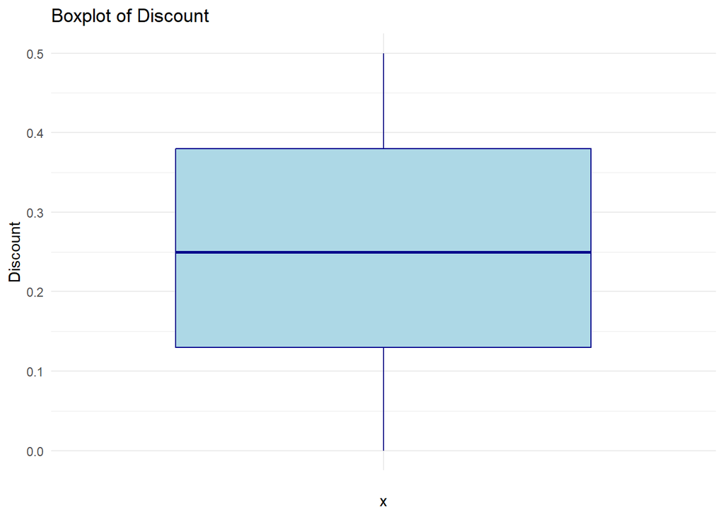

```r
ggplot(data_reduced, aes(x = "", y = Discount)) +
    geom_boxplot(fill = "lightblue", color = "darkblue") +
    labs(title = "Boxplot of Discount", y = "Discount") +
    theme_minimal()
```

```r
kd2_outliers <- function(column) {
  density <- density(column, na.rm = TRUE)
  threshold <- 0.01  # Define a threshold for low-density regions
  outlier_indices <- which(density(column)$y < threshold)
  return(length(outlier_indices))  # Return the count of outliers
}

outliers_quantity <- kd2_outliers(data_reduced$Quantity)
outliers_unit_price <- kd2_outliers(data_reduced$UnitPrice)
outliers_discount <- kd2_outliers(data_reduced$Discount)

cat("Outliers in Quantity:", outliers_quantity, "\n")
```

```
## Outliers in Quantity: 93
```

```r
cat("Outliers in Unit Price:", outliers_unit_price, "\n")
```

```
## Outliers in Unit Price: 287
```

```r
cat("Outliers in Discount:", outliers_discount, "\n")
```

```
## Outliers in Discount: 13
```

```r
remove_kd2_outliers <- function(df, column) {
  density <- density(df[[column]], na.rm = TRUE)
  threshold <- 0.01  # Define a threshold for low-density regions
  outlier_indices <- which(density$y < threshold)
  if (length(outlier_indices) > 0) {
    df <- df[-outlier_indices, ]
  }
  return(df)
}

cleaned_data <- data_reduced %>%
  remove_kd2_outliers("Quantity") %>%
  remove_kd2_outliers("UnitPrice") %>%
  remove_kd2_outliers("Discount")
```

## 3.1 Outliers are Removed

Peak into the cleaned dataset after removing outliers

```r
xkablesummary(cleaned_data)
```

Table: Statistics summary.

|  | InvoiceNo | StockCode | Description | Quantity | InvoiceDate | UnitPrice | CustomerID | Country | Discount | PaymentMethod | ShippingCost | Category | SalesChannel | ReturnStatus | ShipmentProvider | WarehouseLocation | OrderPriority |
| --- | --- | --- | --- | --- | --- | --- | --- | --- | --- | --- | --- | --- | --- | --- | --- | --- | --- |
| Min | Min. :100015 | Length:9611 | Length:9611 | Min. : 1.00 | Length:9611 | Min. : 1.01 | Min. :10003 | Length:9611 | Min. :0.0000 | Length:9611 | Min. : 5.00 | Length:9611 | Length:9611 | Length:9611 | Length:9611 | Length:9611 | Length:9611 |
| Q1 | 1st Qu.:327631 | Class :character | Class :character | 1st Qu.:13.00 | Class :character | 1st Qu.: 25.52 | 1st Qu.:32337 | Class :character | 1st Qu.:0.1300 | Class :character | 1st Qu.:11.06 | Class :character | Class :character | Class :character | Class :character | Class :character | Class :character |
| Median | Median :554318 | Mode :character | Mode :character | Median :24.00 | Mode :character | Median : 50.00 | Median :54951 | Mode :character | Median :0.2500 | Mode :character | Median :17.23 | Mode :character | Mode :character | Mode :character | Mode :character | Mode :character | Mode :character |
| Mean | Mean :551881 | NA | NA | Mean :24.74 | NA | Mean : 50.38 | Mean :54826 | NA | Mean :0.2507 | NA | Mean :17.36 | NA | NA | NA | NA | NA | NA |
| Q3 | 3rd Qu.:777169 | NA | NA | 3rd Qu.:37.00 | NA | 3rd Qu.: 75.16 | 3rd Qu.:77272 | NA | 3rd Qu.:0.3800 | NA | 3rd Qu.:23.62 | NA | NA | NA | NA | NA | NA |
| Max | Max. :999993 | NA | NA | Max. :49.00 | NA | Max. :100.00 | Max. :99980 | NA | Max. :0.5000 | NA | Max. :30.00 | NA | NA | NA | NA | NA | NA |

Converting variables into factors

```r
cleaned_data$InvoiceDate <- as.Date(cleaned_data$InvoiceDate, format = "%d-%m-%Y")
cleaned_data$Description = as.factor(cleaned_data$Description)
cleaned_data$StockCode = as.factor(cleaned_data$StockCode)
cleaned_data$Country = as.factor(cleaned_data$Country)
cleaned_data$PaymentMethod = as.factor(cleaned_data$PaymentMethod)
cleaned_data$Category = as.factor(cleaned_data$Category)
cleaned_data$ReturnStatus = as.factor(cleaned_data$ReturnStatus)
cleaned_data$SalesChannel = as.factor(cleaned_data$SalesChannel)
cleaned_data$ShipmentProvider = as.factor(cleaned_data$ShipmentProvider)
cleaned_data$OrderPriority = as.factor(cleaned_data$OrderPriority)
cleaned_data$WarehouseLocation = as.factor(cleaned_data$WarehouseLocation)
```

```r
str(cleaned_data)
```

```
## 'data.frame':    9611 obs. of  17 variables:
##  $ InvoiceNo        : int  336094 712551 469110 442709 571869 482306 256089 526185 664678 813135 ...
##  $ StockCode        : Factor w/ 1000 levels "SKU_1000","SKU_1001",..: 421 565 76 225 111 521 455 116 206 360 ...
##  $ Description      : Factor w/ 11 levels "Backpack","Blue Pen",..: 11 3 9 9 8 5 4 6 4 6 ...
##  $ Quantity         : int  22 42 12 3 7 7 45 8 46 36 ...
##  $ InvoiceDate      : Date, format: "2020-08-29" "2021-06-21" ...
##  $ UnitPrice        : num  71.9 40.2 56.2 69.6 48.5 ...
##  $ CustomerID       : int  79937 12179 37876 42557 90008 72445 48722 57101 86768 43145 ...
##  $ Country          : Factor w/ 12 levels "Australia","Belgium",..: 10 4 12 10 5 12 3 9 5 4 ...
##  $ Discount         : num  0.23 0.17 0.16 0.36 0.47 0.41 0.24 0.07 0.48 0.46 ...
##  $ PaymentMethod    : Factor w/ 3 levels "Bank Transfer",..: 2 2 1 2 3 3 1 3 2 3 ...
##  $ ShippingCost     : num  14.24 26.88 26 8.37 22.08 ...
##  $ Category         : Factor w/ 5 levels "Accessories",..: 5 2 2 1 2 5 4 5 1 2 ...
##  $ SalesChannel     : Factor w/ 2 levels "In-store","Online": 2 1 2 2 1 1 1 2 1 1 ...
##  $ ReturnStatus     : Factor w/ 2 levels "Not Returned",..: 1 1 1 1 1 1 1 1 1 1 ...
##  $ ShipmentProvider : Factor w/ 4 levels "DHL","FedEx",..: 3 3 3 2 4 3 4 4 3 4 ...
##  $ WarehouseLocation: Factor w/ 5 levels "Amsterdam","Berlin",..: 5 5 4 2 2 5 2 2 3 4 ...
##  $ OrderPriority    : Factor w/ 3 levels "High","Low","Medium": 3 3 1 3 1 2 3 1 3 1 ...
##  - attr(*, "na.action")= 'omit' Named int [1:3921] 5 50 63 72 104 145 148 168 174 177 ...
##   ..- attr(*, "names")= chr [1:3921] "5" "50" "63" "72" ...
```

# 4 Vizualisation

As part of our analysis, we first pre-processed the data to ensure its integrity and completeness, establishing a reliable foundation for subsequent analysis and visualization. With a clean and well-structured dataset, we are now prepared to delve into data visualization and exploration to uncover meaningful patterns and insights.

Data visualization is a crucial element of Exploratory Data Analysis (EDA), offering a way for data analysts to engage visually with the data, which aids in understanding the relationships between variables and identifying potential trends. By creating visual representations, we could effectively interpret the dataset’s underlying structure, facilitating a more intuitive and insightful analysis.**[6]**

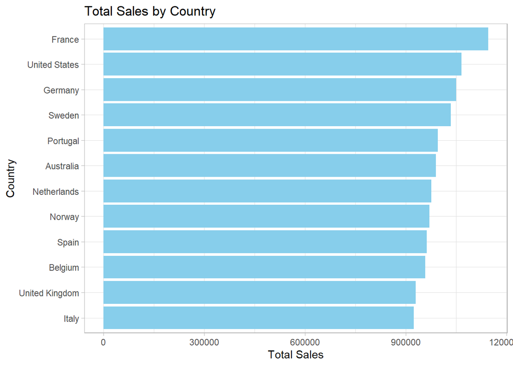

```r
cleaned_data$TotalSales <- cleaned_data$UnitPrice * cleaned_data$Quantity

sales_by_country <- cleaned_data %>%
  group_by(Country) %>%
  summarise(TotalSales = sum(TotalSales, na.rm = TRUE))

# Create the bar plot
ggplot(sales_by_country, aes(x = reorder(Country, TotalSales), y = TotalSales)) +
  geom_bar(stat = "identity", fill = "skyblue") +
  coord_flip() +
  labs(
    title = "Total Sales by Country",
    x = "Country",
    y = "Total Sales"
  ) +
  theme_light()
```

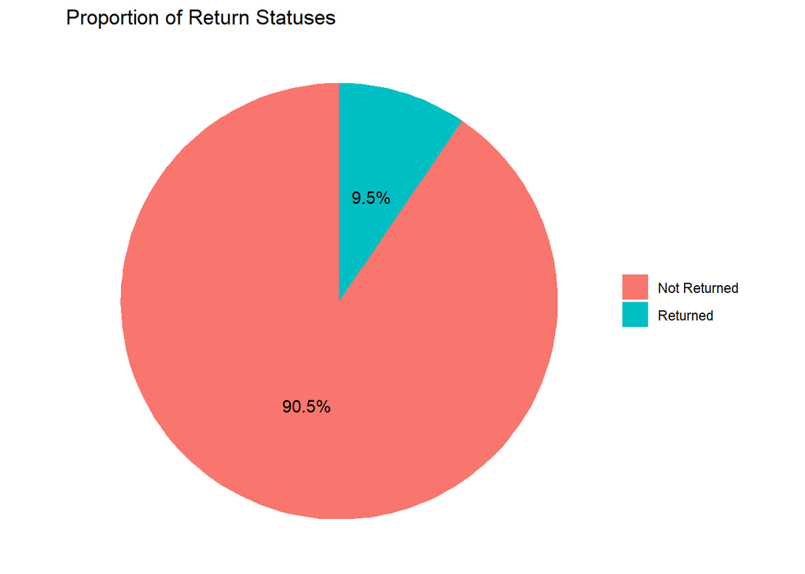

```r
return_status_counts <- cleaned_data %>%
  group_by(ReturnStatus) %>%
  summarise(Count = n()) %>%
  mutate(Percentage = (Count / sum(Count)) * 100)

ggplot(return_status_counts, aes(x = "", y = Count, fill = ReturnStatus)) +
  geom_bar(stat = "identity", width = 1) +
  coord_polar("y", start = 0) +
  geom_text(aes(label = paste0(round(Percentage, 1), "%")), position = position_stack(vjust = 0.5)) +
  labs(
    title = "Proportion of Return Statuses",
    x = NULL,
    y = NULL
  ) +
  theme_void() +
  theme(legend.title = element_blank())
```

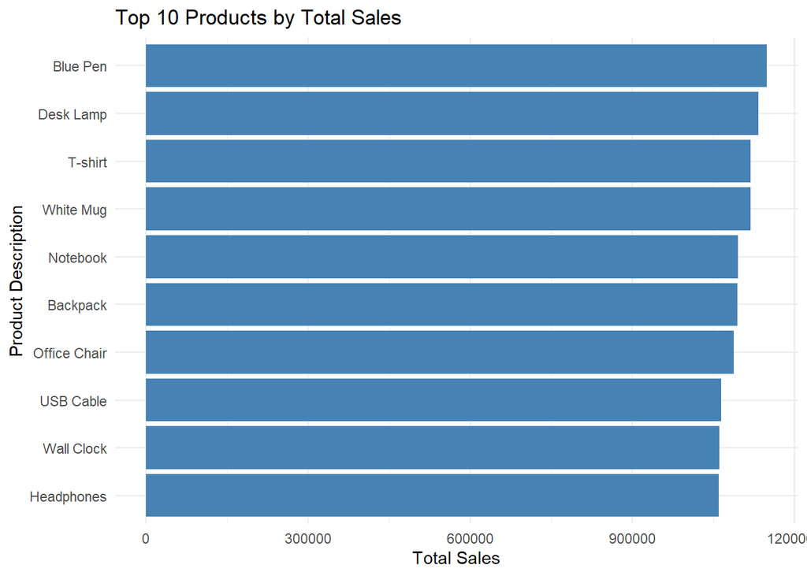

```r
top_products <- cleaned_data %>%
  group_by(Description) %>%
  summarise(TotalSales = sum(UnitPrice * Quantity, na.rm = TRUE)) %>%
  arrange(desc(TotalSales)) %>%
  slice(1:10)

ggplot(top_products, aes(x = reorder(Description, TotalSales), y = TotalSales)) +
  geom_bar(stat = "identity", fill = "steelblue") +
  coord_flip() +
  labs(
    title = "Top 10 Products by Total Sales",
    x = "Product Description",
    y = "Total Sales"
  ) +
  theme_minimal()
```

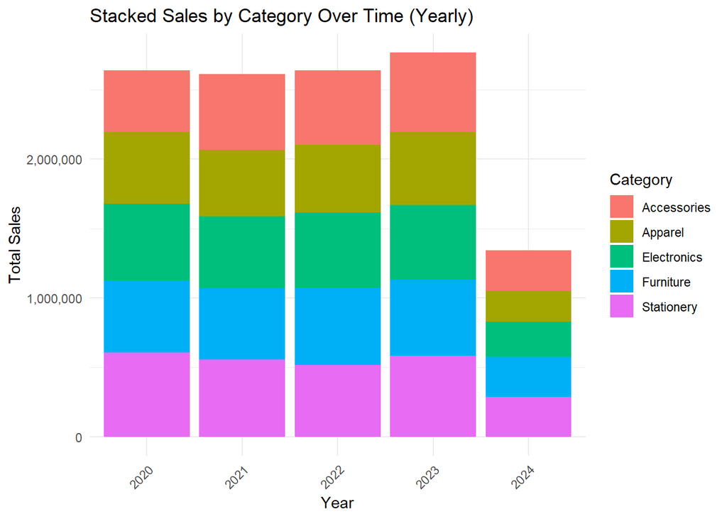

```r
cleaned_data <- cleaned_data %>%
  mutate(Year = format(InvoiceDate, "%Y"))

category_sales_yearly <- cleaned_data %>%
  group_by(Year, Category) %>%
  summarise(
    TotalSales = sum(UnitPrice * Quantity, na.rm = TRUE),
    .groups = "drop"
  )

category_sales_yearly$Year <- factor(category_sales_yearly$Year, levels = unique(category_sales_yearly$Year))

ggplot(category_sales_yearly, aes(x = Year, y = TotalSales, fill = Category)) +
  geom_bar(stat = "identity", position = "stack") +
  labs(
    title = "Stacked Sales by Category Over Time (Yearly)",
    x = "Year",
    y = "Total Sales",
    fill = "Category"
  ) +
  theme_minimal() +
  scale_y_continuous(labels = comma) +
  theme(axis.text.x = element_text(angle = 45, hjust = 1))
```

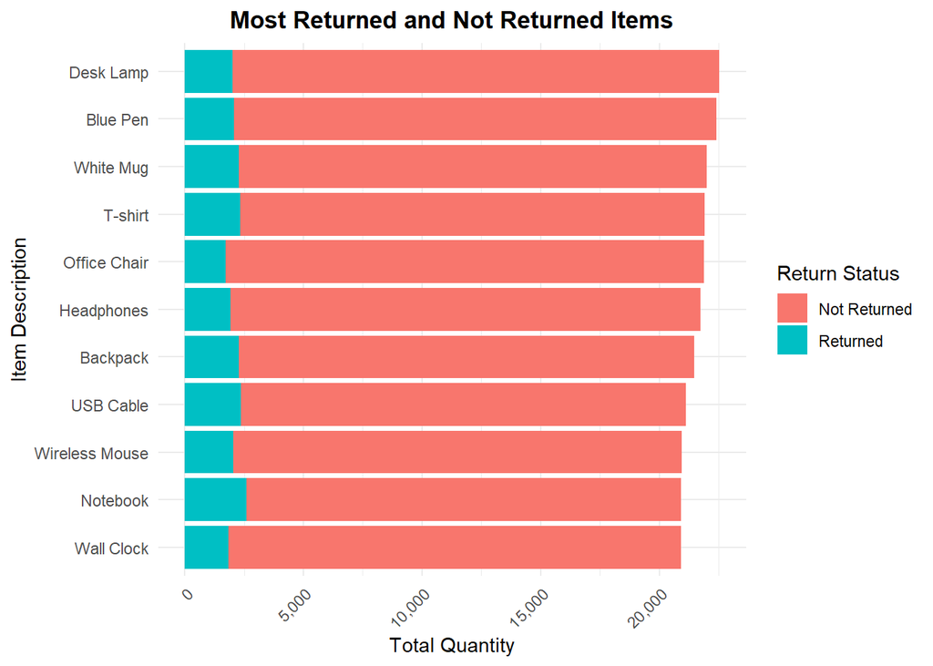

```r
# Summarize total quantities for returned and not-returned items
sales_return_summary <- cleaned_data %>%
  group_by(Description, ReturnStatus) %>%
  summarise(
    TotalQuantity = sum(Quantity, na.rm = TRUE),
    .groups = "drop"
  )
ggplot(sales_return_summary, aes(x = reorder(Description, TotalQuantity), y = TotalQuantity, fill = ReturnStatus)) +
  geom_bar(stat = "identity", position = "stack") +
  labs(
    title = "Most Returned and Not Returned Items",
    x = "Item Description",
    y = "Total Quantity",
    fill = "Return Status"
  ) +
  scale_y_continuous(labels = scales::comma) +
  coord_flip() +
  theme_minimal() +
  theme(
    axis.text.x = element_text(angle = 45, hjust = 1),
    plot.title = element_text(hjust = 0.5, face = "bold")
  )
```

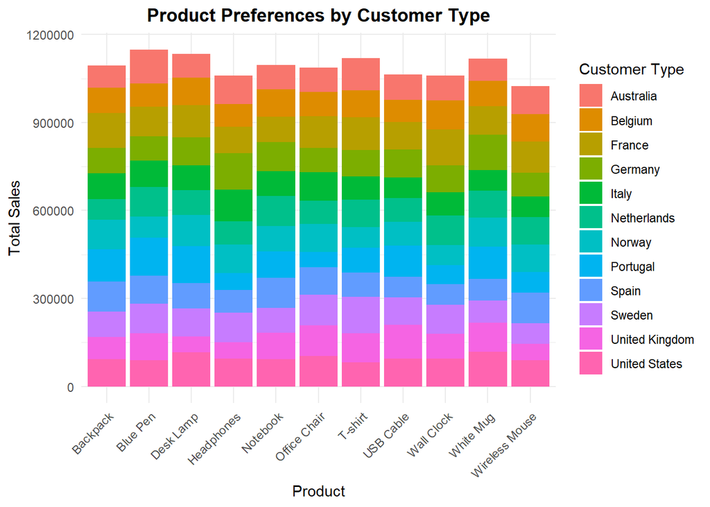

```r
product_preferences <- cleaned_data %>%
  group_by(Description, Country) %>%
  summarise(TotalSales = sum(UnitPrice * Quantity, na.rm = TRUE), .groups = "drop")

ggplot(product_preferences, aes(x = Description, y = TotalSales, fill = Country)) +
  geom_bar(stat = "identity", position = "stack") +
  labs(
    title = "Product Preferences by Customer Type",
    x = "Product",
    y = "Total Sales",
    fill = "Customer Type") +
  theme_minimal() +
  theme(
    axis.text.x = element_text(angle = 45, hjust = 1),
    plot.title = element_text(hjust = 0.5, face = "bold"))
```

# 5 Hypothesis Testing

In an analysis, a hypothesis is a preliminary assumption or prediction based on existing knowledge, which guides exploration and testing. This testing is typically done through statistical methods such as t-tests for mean comparisons or chi-square tests for categorical data relationships, yielding p-values that indicate whether observed patterns are statistically significant.**[7]**

Hypotheses serve as focal points in EDA, helping to frame specific questions and streamline investigation by directing attention toward the most relevant variables and relationships. Through hypothesis testing, assumptions are rigorously evaluated, allowing for meaningful interpretation and robust insights that align with the project’s objectives. By narrowing the focus, hypotheses provide structure and efficiency to EDA, connecting exploratory analysis with deeper inferential statistics or predictive modeling. This approach ensures that findings are not only descriptive but also actionable, enhancing decision-making and potentially shaping strategic direction.

## 5.1 Hypothsis 1

**Alternative Hypothesis (H₁)**: There is a significant association between the mode of payment and customer segmentation based on purchase frequency.

**Mode of Test:** Chi-square test for independence

```r
unique(cleaned_data$PaymentMethod)
```

```
## [1] Credit Card   Bank Transfer paypall
## Levels: Bank Transfer Credit Card paypall
```

```r
payment_segregation <- table(cleaned_data$PaymentMethod, cleaned_data$Category)
chisq_test <- chisq.test(payment_segregation)
print(chisq_test)
```

```
##
##  Pearson's Chi-squared test
##
## data:  payment_segregation
## X-squared = 1.4953, df = 8, p-value = 0.9928
```

## 5.2 Hypothesis 2

**Null Hypothesis (H₀)**: Discounts have no significant impact on the average quantity purchased.

**Alternative Hypothesis (H₁)**: Discounts have a significant impact on the average quantity purchased.

**Mode of Test:** Independent samples t-test

```r
t_test <- t.test(Quantity ~ Discount > 0.1, data = cleaned_data)
print(t_test)
```

```
##
##  Welch Two Sample t-test
##
## data:  Quantity by Discount > 0.1
## t = 1.1254, df = 3140.7, p-value = 0.2605
## alternative hypothesis: true difference in means between group FALSE and group TRUE is not equal to 0
## 95 percent confidence interval:
##  -0.2945428  1.0882599
## sample estimates:
## mean in group FALSE  mean in group TRUE
##            25.05942            24.66256
```

The **p-value** is **greater** than **0.05**, hence we **fail to reject the null hypothesis** and this suggests that discount has no significant impact on average quantity purchased. The confidence interval further indicates that there’s no strong evidence for a significant difference in the average quantity purchased with and without a discount.

## 5.3 Hypothesis 3

**Null Hypothesis (H₀)**: The average shipping cost does not vary significantly between shipment providers.

**Alternative Hypothesis (H₁)**: The average shipping cost varies significantly between shipment providers.

**Mode of Test:** One-way ANOVA

```r
anova <- aov(ShippingCost ~ ShipmentProvider, data = cleaned_data)
summary(anova)
```

```
##                    Df Sum Sq Mean Sq F value Pr(>F)
## ShipmentProvider    3     46   15.20   0.292  0.831
## Residuals        9607 499794   52.02
```

The **p-value** is **greater** than **0.05**, hence we **fail to reject the null hypothesis** and this suggests that there is no significant difference in the average shipping costs between the different shipment providers. And the low F-value is also suggesting that the variation between shipment providers is small compared to the variation within them. In conclusion, the type of shipment provider doesn’t have a strong impact on the cost of shipping.

## 5.4 Hypothesis 4

**Null Hypothesis (H₀)**: There is no significant difference in sales volume between online and in-store channels.

**Alternative Hypothesis (H₁)**: Sales volume differs significantly between online and in-store channels.

**Mode of Test:** Independent samples t-test

```r
t_test2 <- t.test(Quantity ~ SalesChannel, data = cleaned_data)
print(t_test2)
```

```
##
##  Welch Two Sample t-test
##
## data:  Quantity by SalesChannel
## t = -0.079168, df = 9576.2, p-value = 0.9369
## alternative hypothesis: true difference in means between group In-store and group Online is not equal to 0
## 95 percent confidence interval:
##  -0.5887202  0.5430122
## sample estimates:
## mean in group In-store   mean in group Online
##               24.73335               24.75620
```

The **p-value** is **greater** than **0.05**, which means we **fail to reject null hypothesis** and this suggests that there is a statistically no significant difference in sales volume between online and in-store channels. The confidence interval is further supporting the conclusion that there is no significant difference in sales volume between the two channels.

## 5.5 Hypothesis 5

**Null Hypothesis (H₀)**: Return rates are not significantly higher for any particular product category.

**Alternative Hypothesis (H₁)**: Return rates are significantly higher for certain product categories.

**Mode of Test:** Chi-square test for independence

```r
return_category <- table(cleaned_data$ReturnStatus, cleaned_data$Category)
chisq_test2 <- chisq.test(return_category)
print(chisq_test2)
```

```
##
##  Pearson's Chi-squared test
##
## data:  return_category
## X-squared = 1.6165, df = 4, p-value = 0.8058
```

The **p-value** is **greater** than **0.05**, hence we **fail to reject the null hypothesis** and this suggests that there is no significant difference in return rates between the product categories. Based on the result we do not have enough evidence to say that there is an association between the 2 parameters.

## 5.6 Note

**Failing to reject the null hypothesis doesn’t mean the null hypothesis is true—it just means you don’t have enough evidence to reject it.**

# 6 Models

## 6.1 Model 1 - Linear Regression and Regression Tree

**What factors influence total sales revenue, and how can we predict it based on product characteristics, customer demographics and order details?**

We build **Linear Regression** to understand the significant impact of several potential explanatory variables like discounts, quantity sold, order priority, payment methods, and customer region on total sales revenue.

```r
sales_data <- cleaned_data %>%
  group_by(StockCode, OrderPriority, CustomerID) %>%
  summarise(
    avg_discount = mean(Discount, na.rm = TRUE),
    total_sales_revenue = sum(UnitPrice * Quantity, na.rm = TRUE),
    total_quantity_sold = sum(Quantity, na.rm = TRUE),
    .groups = "drop"
  )

customer_data <- cleaned_data %>%
  select(CustomerID, Country, PaymentMethod) %>%
  distinct(CustomerID, .keep_all = TRUE)

sales_data <- sales_data %>%
  left_join(customer_data, by = "CustomerID")
```

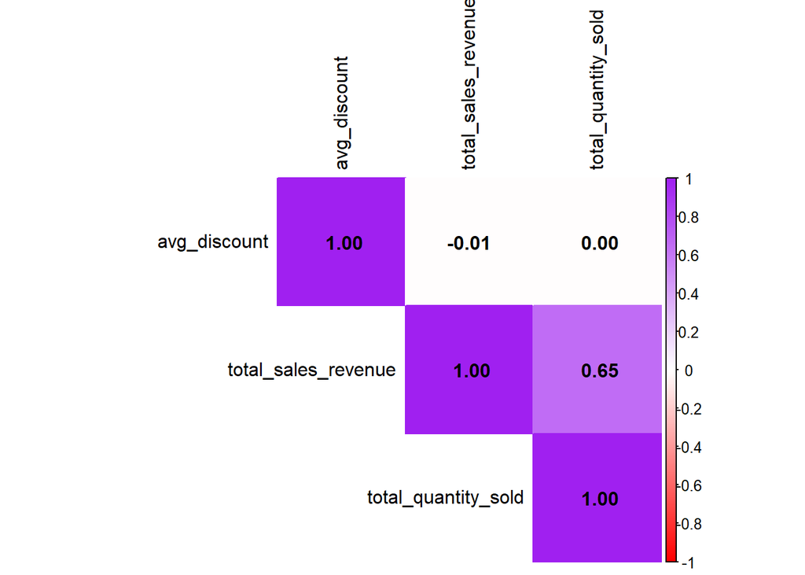

```r
cor_matrix <- cor(sales_data %>% select(avg_discount, total_sales_revenue, total_quantity_sold))

corrplot(
  cor_matrix,
  method = "color",
  type = "upper",
  addCoef.col = "black",
  tl.col = "black",
  col = colorRampPalette(c("red", "white", "purple"))(200))
```

The heatmap reveals that **total quantity sold** has a strong positive correlation (0.65) with **total sales revenue**, indicating it is a key driver of revenue. In contrast, **average discount** shows **negligible correlation** with **total quantity sold** and **no correlation** with **total sales revenue**, suggesting discounts may not significantly impact sales performance. This highlights the need to focus on other strategies to optimize revenue.

We split the data into train and test set where we set 70% of data to be randomly selected as train data and the rest as test data.

```r
set.seed(123)
train_indices1 <- sample(1:nrow(sales_data), 0.7 * nrow(sales_data))
train_data1 <- sales_data[train_indices1, ]
test_data1 <- sales_data[-train_indices1, ]
```

After splitting the data into training and testing sets, we trained the model using avg_discount, OrderPriority, Country, PaymentMethod and total_quantity_sold as predictors of total_sales_revenue.

```r
lm_sales_model <- lm(
  total_sales_revenue ~ avg_discount + OrderPriority + Country + PaymentMethod + total_quantity_sold,
  data = train_data1)

summary(lm_sales_model)
```

```
##
## Call:
## lm(formula = total_sales_revenue ~ avg_discount + OrderPriority +
##     Country + PaymentMethod + total_quantity_sold, data = train_data1)
##
## Residuals:
##      Min       1Q   Median       3Q      Max
## -2406.02  -468.24   -15.64   454.08  2490.95
##
## Coefficients:
##                          Estimate Std. Error t value Pr(>|t|)
## (Intercept)               37.1259    47.6945   0.778   0.4364
## avg_discount             -17.3241    69.3624  -0.250   0.8028
## OrderPriorityLow          -8.5195    24.8562  -0.343   0.7318
## OrderPriorityMedium      -21.7774    24.4913  -0.889   0.3739
## CountryBelgium           -11.5091    50.1470  -0.230   0.8185
## CountryFrance             15.2950    48.4231   0.316   0.7521
## CountryGermany           -19.0571    49.3022  -0.387   0.6991
## CountryItaly              29.3332    49.6023   0.591   0.5543
## CountryNetherlands        -1.6033    49.6512  -0.032   0.9742
## CountryNorway            -13.3485    49.2738  -0.271   0.7865
## CountryPortugal           15.5619    49.1174   0.317   0.7514
## CountrySpain              13.4714    49.9449   0.270   0.7874
## CountrySweden             53.6979    48.2810   1.112   0.2661
## CountryUnited Kingdom     27.7314    50.8363   0.546   0.5854
## CountryUnited States      44.4406    48.7540   0.912   0.3620
## PaymentMethodCredit Card -43.5800    24.6541  -1.768   0.0772 .
## PaymentMethodpaypall     -12.9760    24.7025  -0.525   0.5994
## total_quantity_sold       49.5563     0.7091  69.886   <2e-16 ***
## ---
## Signif. codes:  0 '***' 0.001 '**' 0.01 '*' 0.05 '.' 0.1 ' ' 1
##
## Residual standard error: 824.8 on 6709 degrees of freedom
## Multiple R-squared:  0.4223, Adjusted R-squared:  0.4208
## F-statistic: 288.5 on 17 and 6709 DF,  p-value: < 2.2e-16
```

We evaluate to asses how well our linear regression model is performing.

```r
fitted_values <- lm_sales_model$fitted.values
residuals <- train_data1$total_sales_revenue - fitted_values

MAE <- mean(abs(residuals))
RMSE <- sqrt(mean(residuals^2))

SS_total <- sum((train_data1$total_sales_revenue - mean(train_data1$total_sales_revenue))^2)
SS_residual <- sum(residuals^2)
R_squared <- 1 - (SS_residual / SS_total)

n <- nrow(train_data1)
p <- length(coef(lm_sales_model)) - 1
Adjusted_R_squared <- 1 - ((1 - R_squared) * (n - 1)) / (n - p - 1)

cat("MAE:", MAE, "\n")
```

```
## MAE: 618.3488
```

```r
cat("RMSE:", RMSE, "\n")
```

```
## RMSE: 823.6822
```

```r
cat("R-squared:", R_squared, "\n")
```

```
## R-squared: 0.4223019
```

```r
cat("Adjusted R-squared:", Adjusted_R_squared, "\n")
```

```
## Adjusted R-squared: 0.4208381
```

The model’s evaluation metrics suggest **moderate performance** in predicting total sales revenue. The **R-squared** value of 0.422 indicates that approximately **42% of the variance** in sales revenue is explained by the model, which means there is still considerable unexplained variability. The **Adjusted R-squared** value of 0.421 slightly adjusts for the number of predictors, indicating that the model’s explanatory power is similar even when accounting for the number of features. The **MAE** of 618.35 suggests that, on average, the model’s predictions deviate from actual sales revenue by **618.35 units**. The **RMSE** of 823.68 indicates that larger errors are more significant, with the model often underestimating or overestimating revenue by larger amounts. Overall, while the model provides some useful insights, its prediction accuracy could be improved, possibly by incorporating additional relevant features or exploring alternative modeling techniques.

Since our target variable is total_sales_revenue, which is a continuous numerical variable, we also build a **Regression Tree** to explore non-linear relationships in the data.

```r
regression_tree <- rpart(
  total_sales_revenue ~ avg_discount + OrderPriority + Country + PaymentMethod + total_quantity_sold,data = train_data1,method="anova")
summary(regression_tree)
```

```
## Call:
## rpart(formula = total_sales_revenue ~ avg_discount + OrderPriority +
##     Country + PaymentMethod + total_quantity_sold, data = train_data1,
##     method = "anova")
##   n= 6727
##
##           CP nsplit rel error    xerror       xstd
## 1 0.32131673      0 1.0000000 1.0007529 0.01843382
## 2 0.03983725      1 0.6786833 0.6795723 0.01247594
## 3 0.03693565      2 0.6388460 0.6392815 0.01229022
## 4 0.01000000      3 0.6019104 0.6062599 0.01108708
##
## Variable importance
## total_quantity_sold             Country        avg_discount       PaymentMethod
##                  94                   3                   1                   1
##       OrderPriority
##                   1
##
## Node number 1: 6727 observations,    complexity param=0.3213167
##   mean=1244.189, MSE=1174407
##   left son=2 (3368 obs) right son=3 (3359 obs)
##   Primary splits:
##       total_quantity_sold < 24.5  to the left,     improve=0.3213167000, (0 missing)
##       Country             splits as  RLRLRRLRRRRR, improve=0.0009023859, (0 missing)
##       avg_discount        < 0.495 to the left,     improve=0.0002710183, (0 missing)
##       PaymentMethod       splits as  RLL,          improve=0.0002695582, (0 missing)
##       OrderPriority       splits as  RRL,          improve=0.0001390349, (0 missing)
##   Surrogate splits:
##       Country       splits as  RLLRLRLRLLLR, agree=0.516, adj=0.031, (0 split)
##       avg_discount  < 0.285 to the left,     agree=0.507, adj=0.013, (0 split)
##       PaymentMethod splits as  RRL,          agree=0.507, adj=0.013, (0 split)
##       OrderPriority splits as  LRL,          agree=0.504, adj=0.006, (0 split)
##
## Node number 2: 3368 observations,    complexity param=0.03983725
##   mean=630.7164, MSE=288723.8
##   left son=4 (1669 obs) right son=5 (1699 obs)
##   Primary splits:
##       total_quantity_sold < 12.5  to the left,     improve=3.236492e-01, (0 missing)
##       Country             splits as  RRRLRRLLLRRR, improve=3.340247e-03, (0 missing)
##       avg_discount        < 0.475 to the left,     improve=1.095097e-03, (0 missing)
```

[output cut: 16 more lines]

```
##       OrderPriority       splits as  LRL,          improve=0.0000493983, (0 missing)
##   Surrogate splits:
##       avg_discount < 0.495 to the left,  agree=0.557, adj=0.005, (0 split)
##
## Node number 4: 1669 observations
##   mean=322.2931, MSE=74251.8
##
## Node number 5: 1699 observations
##   mean=933.6936, MSE=314168.3
##
## Node number 6: 1863 observations
##   mean=1595.187, MSE=849929.5
##
## Node number 7: 1496 observations
##   mean=2188.215, MSE=1680558
```

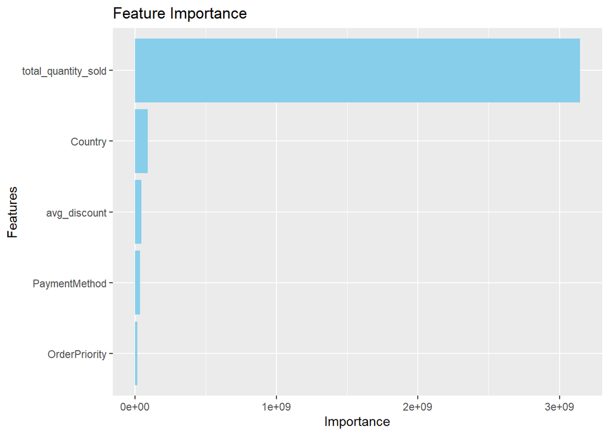

```r
importance_values <- as.data.frame(regression_tree$variable.importance)

var_importance <- data.frame(
  Variable = rownames(importance_values),
  Overall = as.numeric(importance_values$`regression_tree$variable.importance`)
)

rownames(var_importance) <- NULL

ggplot(var_importance, aes(x = reorder(Variable, Overall), y = Overall)) +
  geom_bar(stat = "identity", fill = "skyblue") +
  coord_flip() +
  labs(title = "Feature Importance",x = "Features",
    y = "Importance")
```

The feature importance plot shows that **total_quantity_sold** is the most significant predictor in the regression tree model, dominating the influence on the target variable. Other features, such as **Country** and **avg_discount**, have comparatively much lower importance, indicating their minimal contribution to the model’s predictive power.

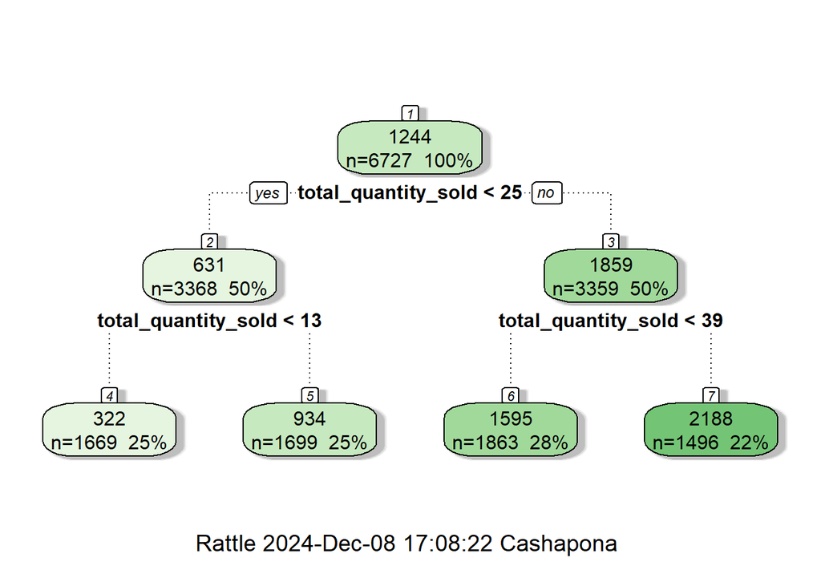

```r
fancyRpartPlot(regression_tree)
```

The regression tree **predicts outcomes** based on the feature **total_quantity_sold**. The root node splits at total_quantity_sold < 25, with further splits refining the predictions based on smaller thresholds. Each leaf node represents the predicted value and its corresponding percentage of data, showing how sales are grouped based on total_quantity_sold.

```r
residuals_tree <- test_data1$total_sales_revenue - predict(regression_tree, test_data1)

MAE_tree <- mean(abs(residuals_tree))
RMSE_tree <- sqrt(mean(residuals_tree^2))

SS_total_tree <- sum((test_data1$total_sales_revenue - mean(test_data1$total_sales_revenue))^2)
SS_residual_tree <- sum(residuals_tree^2)
R_squared_tree <- 1 - (SS_residual_tree / SS_total_tree)

n <- nrow(test_data1)  # number of data points
p <- length(coef(regression_tree))  # number of predictors
Adjusted_R_squared_tree <- 1 - ((1 - R_squared_tree) * (n - 1)) / (n - p - 1)

cat("MAE (Tree):", MAE_tree, "\n")
```

```
## MAE (Tree): 631.9208
```

```r
cat("RMSE (Tree):", RMSE_tree, "\n")
```

```
## RMSE (Tree): 830.0278
```

```r
cat("R-squared (Tree):", R_squared_tree, "\n")
```

```
## R-squared (Tree): 0.4148201
```

```r
cat("Adjusted R-squared (Tree):", Adjusted_R_squared_tree, "\n")
```

```
## Adjusted R-squared (Tree): 0.4148201
```

The model’s evaluation metrics suggest **moderate performance** in predicting total sales revenue. The **R-squared** value of 0.415 indicates that approximately **41.5% of the variance** in sales revenue is explained by the regression tree model, leaving a significant portion of variability unexplained. The **Adjusted R-squared** value of 0.415 is consistent with the R-squared, indicating that the model’s explanatory power remains similar even after adjusting for the number of predictors. The **MAE** of 631.92 suggests that, on average, the model’s predictions deviate from actual sales revenue by **631.92 units**. The **RMSE** of 830.03 shows that larger prediction errors are more significant, with the model tending to make larger underestimation or overestimation. Overall, while the model provides some insight into the factors driving sales revenue, its prediction accuracy can still be improved by adding more relevant features or trying other modeling approaches.

## 6.2 Model 2 - Classification Tree and Logistic Regression

**Which order characteristics significantly influence the likelihood of a sale occurring online versus in-store, and how can we use these factors to classify sales channels?**

We build **Classification Tree** model to classify customers into predefined segments based on predictors like purchase frequency, product preferences, and payment methods.

```r
customer_data <- cleaned_data %>%
  group_by(CustomerID) %>%
  summarize(
    purchase_frequency = n_distinct(InvoiceNo),
    total_quantity = sum(Quantity, na.rm = TRUE),
    total_spend = sum(UnitPrice * Quantity, na.rm = TRUE),
    avg_discount = mean(Discount, na.rm = TRUE),
    preferred_payment = as.character(names(sort(table(PaymentMethod), decreasing = TRUE)[1])),
    preferred_category = as.character(names(sort(table(Category), decreasing = TRUE)[1]))
  )

spend_summary <- summary(customer_data$total_spend)
low_threshold <- spend_summary["1st Qu."]
high_threshold <- spend_summary["3rd Qu."]

customer_data <- customer_data %>%
  mutate(
    customer_segment = case_when(
      total_spend < low_threshold ~ "Low",
      total_spend >= low_threshold & total_spend < high_threshold ~ "Medium",
      total_spend >= high_threshold ~ "High"
    )
  )

customer_data$preferred_payment <-  as.factor(customer_data$preferred_payment)

customer_data$preferred_category <- as.factor(customer_data$preferred_category)


customer_data$preferred_payment <- as.numeric(customer_data$preferred_payment)

customer_data$preferred_category <- as.numeric(customer_data$preferred_category)
```

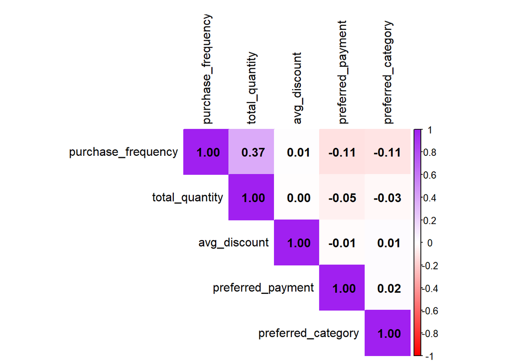

```r
cor_matrix <- cor(customer_data %>%
                    select(purchase_frequency, total_quantity, avg_discount, preferred_payment, preferred_category),
                  use = "complete.obs")

corrplot(
  cor_matrix,
  method = "color",
  type = "upper",
  addCoef.col = "black",
  tl.col = "black",
  col = colorRampPalette(c("red", "white", "purple"))(200),
 mar = c(0, 0, 1, 0))
```

The heatmap shows that **purchase_frequency** and **total_quantity** have a moderate positive correlation, indicating frequent purchasers tend to buy more items. Other variables, such as **avg_discount**, **preferred_payment**, and **preferred_category**, show weak or no linear correlations with others. This suggests **purchase_frequency** and **total_quantity** might be the most relevant predictors, while other features could contribute in nonlinear ways.

We aggregate features by grouping CustomerID. Then we define the customer_segment variable based on total_spend and categorized customers into “Low,” “Medium,” and “High” segments. Next we convert and encode preferred_payment and preferred_category to numeric form for model compatibility. We split the data into train and test set where we set 70% of data to be randomly selected as train data and the rest as test data. Then we apply the classification tree model.

```r
set.seed(123)
train_indices <- sample(1:nrow(customer_data), 0.7 * nrow(customer_data))
train_data <- customer_data[train_indices, ]
test_data <- customer_data[-train_indices, ]


classification_tree <- rpart(
  customer_segment ~ purchase_frequency + total_quantity + avg_discount + preferred_payment + preferred_category,
  data = train_data,
  method = "class"
)

summary(classification_tree)
```

```
## Call:
## rpart(formula = customer_segment ~ purchase_frequency + total_quantity +
##     avg_discount + preferred_payment + preferred_category, data = train_data,
##     method = "class")
##   n= 6379
##
##           CP nsplit rel error    xerror       xstd
## 1 0.20587307      0 1.0000000 1.0000000 0.01260920
## 2 0.05841490      1 0.7941269 0.7941269 0.01232433
## 3 0.02068203      2 0.7357120 0.7335017 0.01213526
## 4 0.01000000      4 0.6943480 0.6962425 0.01199378
##
## Variable importance
## total_quantity
##             99
##
## Node number 1: 6379 observations,    complexity param=0.2058731
##   predicted class=Medium  expected loss=0.4964728  P(node) =1
##     class counts:  1576  1591  3212
##    probabilities: 0.247 0.249 0.504
##   left son=2 (1002 obs) right son=3 (5377 obs)
##   Primary splits:
##       total_quantity     < 8.5    to the left,  improve=595.4336000, (0 missing)
##       purchase_frequency < 1.5    to the right, improve= 60.4782200, (0 missing)
##       avg_discount       < 0.42   to the left,  improve=  1.7737920, (0 missing)
##       preferred_payment  < 1.5    to the left,  improve=  1.3354420, (0 missing)
##       preferred_category < 2.5    to the left,  improve=  0.4817968, (0 missing)
##
## Node number 2: 1002 observations
##   predicted class=Low     expected loss=0.1746507  P(node) =0.1570779
##     class counts:     0   827   175
##    probabilities: 0.000 0.825 0.175
##
## Node number 3: 5377 observations,    complexity param=0.0584149
##   predicted class=Medium  expected loss=0.4351869  P(node) =0.8429221
##     class counts:  1576   764  3037
##    probabilities: 0.293 0.142 0.565
##   left son=6 (2910 obs) right son=7 (2467 obs)
##   Primary splits:
##       total_quantity     < 27.5   to the right, improve=391.4940000, (0 missing)
```

[output cut: 40 more lines]

```
##       preferred_category < 2.5    to the right, improve= 0.7717805, (0 missing)
##       preferred_payment  < 1.5    to the left,  improve= 0.3992900, (0 missing)
##   Surrogate splits:
##       avg_discount       < 0.1325 to the right, agree=0.517, adj=0.010, (0 split)
##       preferred_category < 3.5    to the left,  agree=0.514, adj=0.004, (0 split)
##
## Node number 26: 1429 observations
##   predicted class=High    expected loss=0.4597621  P(node) =0.2240163
##     class counts:   772   102   555
##    probabilities: 0.540 0.071 0.388
##
## Node number 27: 1364 observations
##   predicted class=Medium  expected loss=0.5014663  P(node) =0.2138266
##     class counts:   549   135   680
##    probabilities: 0.402 0.099 0.499
```

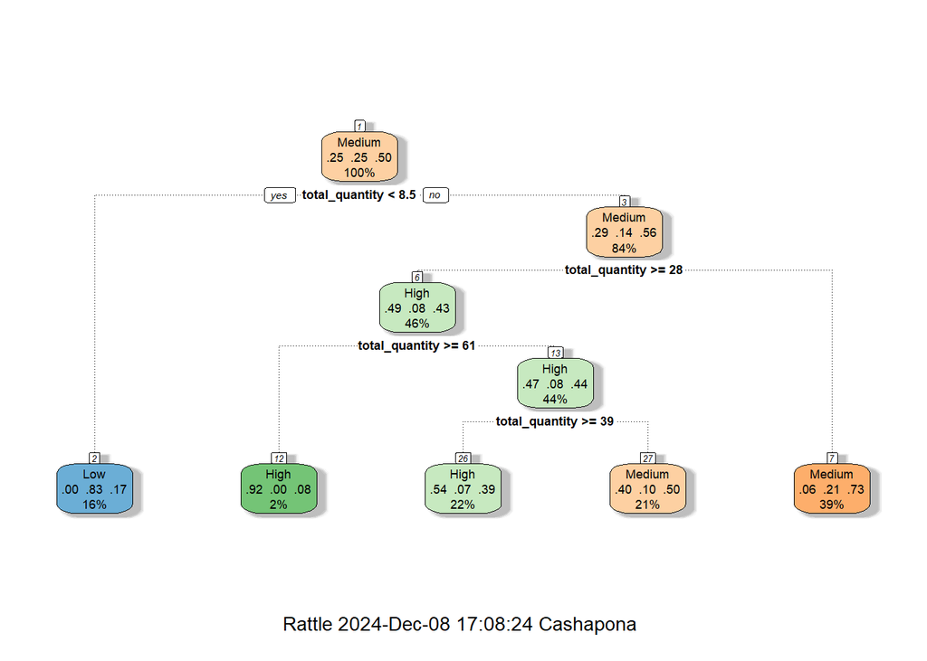

```r
fancyRpartPlot(classification_tree)
```

```r
predictions <- predict(classification_tree, test_data, type = "class")
test_data$predicted_segment <- predictions
```

```r
confusion_matrix <- table(Actual = test_data$customer_segment, Predicted = test_data$predicted_segment)
print(confusion_matrix)
```

```
##         Predicted
## Actual   High  Low Medium
##   High    399    0    304
##   Low      54  341    292
##   Medium  234  101   1009
```

This confusion matrix evaluates a classification model’s performance. The diagonal values represent correct predictions, with the model performing best for the **Medium class** (1009 correct). Significant confusion exists between **High** and **Medium classes**, with many misclassifications (e.g., 304 High predicted as Medium). Improving feature representation or using a different model could enhance accuracy.

```r
accuracy <- sum(diag(confusion_matrix)) / sum(confusion_matrix)
cat("Accuracy:", accuracy, "\n")
```

```
## Accuracy: 0.639722
```

The classification tree model achieved an accuracy of **63.97%**, meaning it correctly predicted approximately 64% of the instances in the dataset. While this shows moderate performance, the model struggles with misclassifications, as seen in the confusion matrix, particularly between `High` and `Medium` categories. Further tuning, feature engineering, or trying alternative models may improve this result.

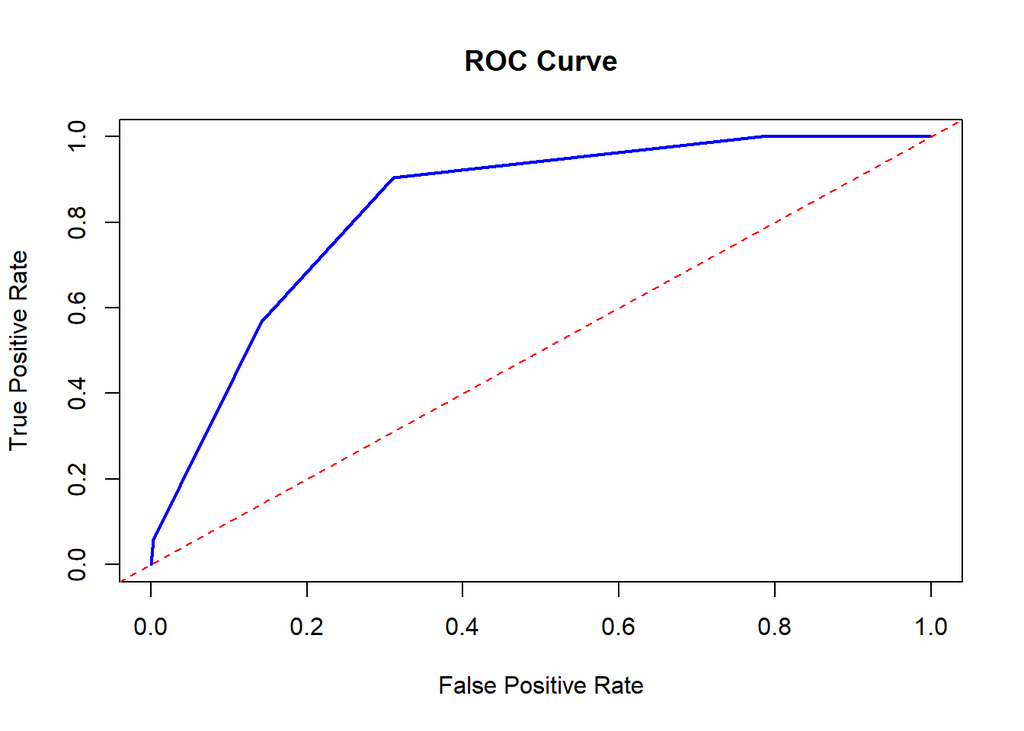

```r
predicted_probs <- predict(classification_tree, test_data, type = "prob")

actual <- ifelse(test_data$customer_segment == "High", 1, 0)
predicted <- predicted_probs[, "High"]

thresholds <- seq(0, 1, by = 0.01)
tpr <- c()
fpr <- c()

for (threshold in thresholds) {
  predicted_class <- ifelse(predicted >= threshold, 1, 0)

  tp <- sum(predicted_class == 1 & actual == 1)
  fp <- sum(predicted_class == 1 & actual == 0)
  fn <- sum(predicted_class == 0 & actual == 1)
  tn <- sum(predicted_class == 0 & actual == 0)

  tpr <- c(tpr, tp / (tp + fn))
  fpr <- c(fpr, fp / (fp + tn))
}

plot(fpr, tpr, type = "l", col = "blue", lwd = 2, xlab = "False Positive Rate", ylab = "True Positive Rate",
     main = "ROC Curve")
abline(a = 0, b = 1, col = "red", lty = 2)
```

```r
sortedindices = order(fpr)
fpr = fpr[sortedindices]
tpr = tpr[sortedindices]

auc = sum((fpr[-1] - fpr[-length(fpr)]) * (tpr[-1] + tpr[-length(tpr)]) / 2)

cat("AUC:",auc, "\n")
```

```
## AUC: 0.834802
```

The **ROC curve** evaluates the model’s ability to classify “High” customer segments, with the blue line showing the trade-off between True Positive Rate (sensitivity) and False Positive Rate. The curve’s proximity to the top-left corner indicates good classification performance, significantly better than the random classifier (red dashed line). A higher AUC (Area Under the Curve) reflects better overall model accuracy in distinguishing “High” from non-“High” customers.

Next we build **Logistic Regression** model to predict whether a sale occurs online or in-store, focusing on order characteristics. To prepare the dataset, we encoded the sales channel as a binary variable (SalesChannel), where “Online” was represented as 1 and “In-store” as 0. Key predictors like quantity, unit price, discount, order priority, country, and payment method were selected, ensuring that categorical variables were converted to factors for compatibility with the model.

```r
logistic_data <- cleaned_data %>%
  mutate(
    SalesChannel = ifelse(SalesChannel == "Online", 1, 0)
  ) %>%
  select(
    SalesChannel, CustomerID, Quantity, UnitPrice, Discount, OrderPriority, Country, PaymentMethod
  )
```

We split the data into training and testing sets, with 70% of the data used for training. The model was then trained using Quantity, UnitPrice, Discount, OrderPriority, Country, and PaymentMethod as predictors.

```r
set.seed(123)
train_indices <- sample(1:nrow(logistic_data), 0.7 * nrow(logistic_data))
train_data <- logistic_data[train_indices, ]
test_data <- logistic_data[-train_indices, ]


logistic_model <- glm(
  SalesChannel ~ Quantity + UnitPrice + Discount + OrderPriority + Country + PaymentMethod,
  data = train_data,
  family = "binomial"
)

summary(logistic_model)
```

```
##
## Call:
## glm(formula = SalesChannel ~ Quantity + UnitPrice + Discount +
##     OrderPriority + Country + PaymentMethod, family = "binomial",
##     data = train_data)
##
## Coefficients:
##                            Estimate Std. Error z value Pr(>|z|)
## (Intercept)               0.0641748  0.1237819   0.518    0.604
## Quantity                  0.0011879  0.0017268   0.688    0.491
## UnitPrice                -0.0008689  0.0008507  -1.021    0.307
## Discount                 -0.1219021  0.1689529  -0.722    0.471
## OrderPriorityLow         -0.0888111  0.0601353  -1.477    0.140
## OrderPriorityMedium      -0.1293781  0.0596325  -2.170    0.030 *
## CountryBelgium            0.0282127  0.1211441   0.233    0.816
## CountryFrance             0.0045944  0.1173933   0.039    0.969
## CountryGermany           -0.0432914  0.1190466  -0.364    0.716
## CountryItaly              0.0387475  0.1216035   0.319    0.750
## CountryNetherlands       -0.0048777  0.1206986  -0.040    0.968
## CountryNorway            -0.0600368  0.1200079  -0.500    0.617
## CountryPortugal          -0.0060399  0.1197303  -0.050    0.960
## CountrySpain              0.1088914  0.1198182   0.909    0.363
## CountrySweden             0.0477098  0.1198877   0.398    0.691
## CountryUnited Kingdom    -0.0023992  0.1210885  -0.020    0.984
## CountryUnited States     -0.0958419  0.1201152  -0.798    0.425
## PaymentMethodCredit Card -0.0265552  0.0600606  -0.442    0.658
## PaymentMethodpaypall      0.0211644  0.0598627   0.354    0.724
## ---
## Signif. codes:  0 '***' 0.001 '**' 0.01 '*' 0.05 '.' 0.1 ' ' 1
##
## (Dispersion parameter for binomial family taken to be 1)
##
##     Null deviance: 9320.6  on 6726  degrees of freedom
## Residual deviance: 9309.1  on 6708  degrees of freedom
## AIC: 9347.1
##
## Number of Fisher Scoring iterations: 3
```

```r
predicted_probabilities <- predict(logistic_model, test_data, type = "response")
test_data$predicted_channel <- ifelse(predicted_probabilities > 0.5, 1, 0)
```

```r
confusion_matrix <- table(Actual = test_data$SalesChannel, Predicted = test_data$predicted_channel)
print(confusion_matrix)
```

```
##       Predicted
## Actual    0    1
##      0 1064  375
##      1 1071  374
```

```r
performance <- confusionMatrix(factor(test_data$predicted_channel), factor(test_data$SalesChannel))

accuracy <- performance$overall["Accuracy"]
print(accuracy)
```

```
## Accuracy
## 0.498613
```

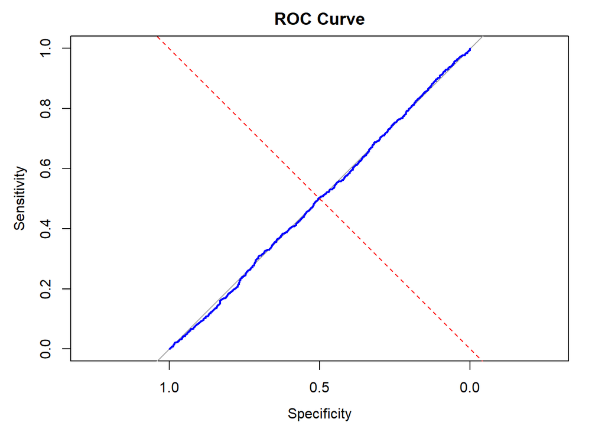

```r
predicted_probs = predict(logistic_model, test_data, type = "response")

roc_curve= roc(test_data$SalesChannel, predicted_probabilities)
plot(roc_curve, col = "blue", lwd = 2, main = "ROC Curve")
abline(a = 0, b = 1, col = "red", lty = 2)
```

```r
auc_value = auc(roc_curve)
cat("AUC:", auc_value, "\n")
```

```
## AUC: 0.4965198
```